# A first tutorial for ‘gscramble’

```r
library(gscramble)
library(tidyverse)
```

## Input Data

‘gscramble’ operates only for diploid species. The main functions in `gscramble` require that genetic data be provided in R objects (matrices/tibbles/etc.) with particular formatting. We describe the formats of those objects here. Later, in the section, To and From plink Format, we describe functions for reading data from PLINK (.ped / .map) format (and perhaps others, in the future) into these necessary objects for ‘gscramble’.

The main required objects (loosely aligning with .bed/.fam/.bim file structure of binary PLINK files) are:

1. A matrix of genotype data (the `Geno` object included with the package as example data)
2. A tibble of meta data about the individuals in the genotype data (`I_meta` as example data)
3. A tibble of meta data about the markers in the genotype data (`M_meta` as example data)

In addition to these objects, if you want to simulate hybrid individuals according to a pedigree, you will need to provide:

4. A tibble that describes the rates of genetic recombination along the chromosomes (`RecRates`)
5. A tibble that describes a pedigree of interest within which sections of chromosomes are segregated down successive generations, which we call a “genome simulation pedigree” (`GSP`)
6. A tibble that translates the population specifiers in the pedigree (i.e., `GSP`) with the population/group labels associated with the genetic data (i.e., `I_meta`) for different hybridization replicates (`RepPop`)

Examples of these objects (which have been heavily downsampled to make them small enough to host on CRAN) illustrating 78 individuals genotyped at 100 loci distributed across 3 chromosomes (chr 12, 17, & 18) and sampled from 4 groups (Pop1, 2, 3, 4) from a data set of invasive feral swine, are included as data objects with the package (`Geno`, `I_meta`, and `M_meta`). The full data set, from which the package data were downsampled, was used in Smyser et al. (2020), and is available at https://datadryad.org/stash/dataset/doi:10.5061/dryad.jsxksn05z.

### Matrix of genotype data. `Geno`

The genotype data must be provided in a matrix. If there are $N$ individuals and $L$ loci in the diploid species, this matrix has $N$ rows and $2L$ columns. Each locus gets two adjacent columns (one allele in each column) and each individual gets one row. For example, in the first row and first column `Geno[1,1]` is the first allele for the first locus for the first individual. In the first row and second column `Geno[1,2]` is the second allele for the first locus for the first individual. In the first row and third column `Geno[1,3]` is the first allele at the second locus for the first individual, and so on.

The names/IDs of the individuals must be included as the the rownames of the matrix of genotypes.

Here is an example of the first 6 loci for the first 4 individuals from the data included with the package as `Geno`:

```r
Geno[1:4, 1:12]
```

```
#>           [,1] [,2] [,3] [,4] [,5] [,6] [,7] [,8] [,9] [,10] [,11] [,12]
#> ID0033692 "G"  "G"  NA   NA   "T"  "T"  "A"  "A"  "G"  "G"   "T"   "T"
#> ID0014942 "G"  "G"  "C"  "C"  "T"  "T"  "A"  "A"  "G"  "G"   "T"   "T"
#> ID0014961 "G"  "G"  "C"  "C"  "T"  "T"  "A"  "A"  "G"  "G"   "T"   "T"
#> ID0016971 "G"  "G"  "C"  "C"  "T"  "T"  NA   NA   "G"  "G"   "T"   "T"
```

These data must be stored as a **character Matrix**. Don’t pass in a matrix of integers. The alleles can be any characters whatsoever. This allows the data to be microsatellites, (`"112"`, `"116"`, etc), or microhaplotypes (`"ACCGA"`, `"ACCTC"`, etc.), or SNPs (`"A"`, `"C"`, `"G"`, `"T"`), etc. If you do have a matrix of integers, named, for example `IntMat`, you can coerce all the elements of that matrix to be characters without losing the matrix shape of the data, by doing this:

```r
storage.mode(IntMat) <- "character"
```

Missing genotype data must be denoted by the standard R missing-data specifier, `NA`. Don’t specify missing data as `"-1"` and expect it to work properly! Change those `"-1"`’s to `NA`s, or they will be regarded as an allelic type, rather than as missing data. If you do have missing data that are denoted as `"-1"`, for example, then you can change all those `"-1"`’s to `NA`s using the following:

```r
Geno[Geno == "-1"] <- NA
```

Presently, since there are no `"-1"` entries in the `Geno` dataset, this line changes nothing.

### Individual meta data. `I_meta`

This is a tibble that gives information about the individuals whose genotypes are in `Geno`. This can have as many different columns as you want, but there must be at least two columns:

- `group`: a column that gives the character name of the group/cluster/population that each individual is considered to be a part of.
- `indiv`: a column that gives the character ID of each individual.

The number of rows of this tibble should be exactly equal to the number of rows on `Geno` *and* the order of individuals in `I_meta` must correspond exactly to the order of individuals in `Geno`.

Here is what the first few rows from the example data `I_meta` look like:

```r
head(I_meta)
```

```
#> # A tibble: 6 × 2
#>   group indiv
#>   <chr> <chr>
#> 1 Pop1  ID0033692
#> 2 Pop1  ID0014942
#> 3 Pop1  ID0014961
#> 4 Pop1  ID0016971
#> 5 Pop1  ID0016972
#> 6 Pop1  ID0017013
```

### Marker meta data. `M_meta`

There must be exactly half as many rows in `M_meta` as there are columns in `Geno`, and the order of markers in `M_meta` must correspond exactly to the order of markers in the columns in `Geno`.

Here are the first few rows of the example data `M_meta`:

```r
head(M_meta)
```

```
#> # A tibble: 6 × 3
#>   chrom      pos variant_id
#>   <chr>    <dbl> <chr>
#> 1 12     4469057 WU_10.2_12_4469057
#> 2 12     5238225 ALGA0064411
#> 3 12     7394362 WU_10.2_12_7394362
#> 4 12     7651064 ASGA0090707
#> 5 12     8971475 WU_10.2_12_8971475
#> 6 12    11034660 WU_10.2_12_11034660
```

### Recombination rates. `RecRates`

- `chrom`: the chromosome on which the bin occurs. Note that the chromosome nomenclature must match exactly that used in `M_meta`.
- `chrom_len`: the length of the chromosome. Yes, the value for each chromosome will be the same for each marker/row associated with a given `chrom`.
- `start_pos`: the starting position of the bin. This will typically be a position along the chromosome in base pairs, though this position can be in some other units, so long as it corresponds to the position used in `M_meta`.
- `end_pos`: the ending position of the bin.
- `rec_prob`: the per-meiosis probability of a recombination occurring in the bin.

There are some important notes:

1. The start point of a bin should be 1 greater than the end point of the preceding bin.
2. The positions of all the markers (in `M_meta`) should be included amongst the bin intervals defined by `start_pos` and `end_pos`. Most crucially in this regard, the smallest `start_pos` should be less than the smallest `pos` in `M_meta` and the greatest `end_pos` should be greater than or equal to the largest `pos` in `M_meta`. To enforce the latter, it is required that the `end_pos` of the rightmost bin on each chromosome must be 1 greater than the chromosome length. Otherwise, recombination might never be possible between some pairs of markers in the data set.
3. The chromosome length in `chrom_len` **must** exceed the position of every marker on the chromosome in `M_meta`. If this is not the case then it would be possible that some markers would be dropped from the data set, possibly with unexpected or bad results. You can check for errors in this regard by making sure that you pass your marker meta data (`M_meta` in this example) to the `MM` option of the `segregate()` function (see below).

```r
head(RecRates)
```

```
#> # A tibble: 6 × 5
#>   chrom chrom_len start_pos end_pos rec_prob
#>   <chr>     <dbl>     <dbl>   <dbl>    <dbl>
#> 1 12     63582536         1   79501 0.000694
#> 2 12     63582536     79502 1573908 0.00131
#> 3 12     63582536   1573909 2097503 0.000554
#> 4 12     63582536   2097504 3308663 0.00557
#> 5 12     63582536   3308664 4021031 0.0179
#> 6 12     63582536   4021032 5026780 0.0115
```

#### Making a `RecRates`-like tibble from a plink map file

The package includes a function `plink_map2rec_rates()` that will turn a plink map file into a tibble formatted like `RecRates`. Read the documentation for it with `?plink_map2rec_rates`.

### Genome Simulation Pedigree. `GSP`

The `GSP` is a specification of a pedigree within which sections of chromosome will get segregated across the successive generations represented within the pedigree and is used to to guide sampling of these chromosomal sections without replacement. This will allow us to characterize/simulate hybrid individuals for the purpose of assessing the power to classify individuals to hybrid classes of interest (i.e., F1s, F1BC1s, F2BC1s, etc.).

The `GSP` must be a tibble in which each individual has a numeric identifier (from 1 up to the number of individuals in the pedigree). Founders are listed directly (1…nFounders) whereas numbers can represent more than one individual in successive generations (e.g., two F1 individuals sampled within the most basic pedigree illustrated below are characterized as ‘3’). The founders’ parents are listed as NA whereas non-founders have parents listed. Founders’ haplotypes must have unique IDs and must originate from a specified population (typically given in capital letters.) Individuals can be sampled from individuals in the pedigree, and it is up to the user to indicate how many gametes must be segregated to each individual (from each of its two parents) in order to consume all the genetic material present among the founders.

This probably sounds a little abstract, and, indeed, it is. To demonstrate, ‘gscramble’ includes 15 basic GSPs (illustrated within the object `GSP_opts`) that can be retrieved by specifying the types of individuals of interest with the function `create_GSP()`. As we will illustrate below, you are not restricted to these GSP configurations. These 15 specific GSP configurations were of interest to the authors and are included to illustrate how to structure GSP tibbles that may be of interest to you.

To try to explain the GSP concept more fully, we will first draw a picture of the most basic pedigree (the simulation of F1s created through the hybridization of individuals from two populations). We then show the tibble representation of that same GSP and discuss the structure of a GSP in light of those two pieces of information.

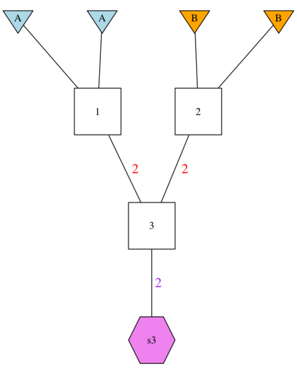

**A Simple GSP.** Here we have a pedigree with diploid founder ‘1’, who is formed by the union of two gametes from Population A, and diploid founder ‘2’ with two gametes from Population B. Founder ‘1’ and founder ‘2’ then pass 2 gametes (red 2’s) for the formation of 2 individuals represented by their descendant ‘box 3’. The pink hexagon ‘s3’ then represents the samples taken from ‘box 3’ with the pink 2 used to indicate the number of diploid individuals sampled.

Let’s develop this basic example of simulating F1 hybrids. The first step would be to define the GSP in which we are describing sources as ‘p1’ and ‘p2’, and then we will need an associated `RepPop` to represent the two different populations the founders belong to.

```r
gspF1 <- create_GSP(pop1 = "p1", pop2 = "p2", F1 = TRUE)

gspF1
```

```
#> # A tibble: 3 × 11
#>     ind  par1  par2 ipar1 ipar2 hap1  hap2  hpop1 hpop2 sample osample
#>   <dbl> <dbl> <dbl> <dbl> <dbl> <chr> <chr> <chr> <chr> <chr>    <dbl>
#> 1     1    NA    NA    NA    NA 1a    1b    p1    p1    <NA>        NA
#> 2     2    NA    NA    NA    NA 2a    2b    p2    p2    <NA>        NA
#> 3     3     1     2     2     2 <NA>  <NA>  <NA>  <NA>  s3           2
```

To accompany this GSP, we next need to define the groups that we are interested in hybridizing - in this case Pop1 and Pop2 - with a `RepPop` tibble.

We will fully describe `RepPop` tibbles below. However, GSPs need to be accompanied by a `RepPop` tibble that defines the groups to be hybridized. Accordingly, let’s lightly introduce the `RepPop` object here by specifying the tibble that accompanies this F1 GSP.

```r
Pattern = c("Pop1", "Pop2")
RepPopSimpleF1 <- tibble(
  index = rep(1:1, each = 2),
  pop = rep(c("p1", "p2"), times = 1),
  group = Pattern
)
RepPopSimpleF1
```

```
#> # A tibble: 2 × 3
#>   index pop   group
#>   <int> <chr> <chr>
#> 1     1 p1    Pop1
#> 2     1 p2    Pop2
```

Please note that F1s are symmetrical, such that a Pop1-Pop2 F1 hybrid is identical to a Pop2-Pop1 F1 hybrid. This will not be the case as we continue developing more complex GSPs that include backcrossed hybrids.

This simplistic example specifies F1 hybrids between Pop1 and Pop2. If we want to  
add a little more complexity working within the same GSP, we could modify the `RepPop` tibble to simulate hybrids between Pop1 and all other populations.

```r
Pattern = c("Pop1", "Pop2", "Pop1",
            "Pop3", "Pop1", "Pop4")
RepPopSimpleF1_b <- tibble(
  index = rep(1:3, each = 2),
  pop = rep(c("p1", "p2"), times = 3),
  group = Pattern
)
RepPopSimpleF1_b
```

```
#> # A tibble: 6 × 3
#>   index pop   group
#>   <int> <chr> <chr>
#> 1     1 p1    Pop1
#> 2     1 p2    Pop2
#> 3     2 p1    Pop1
#> 4     2 p2    Pop3
#> 5     3 p1    Pop1
#> 6     3 p2    Pop4
```

Or, perhaps, let’s say you are interested in simulating F1 hybrids for all pairwise combinations of populations (with the example data Pop1, Pop2, Pop3, Pop4).  
Accordingly, we need to specify the `RepPop` tibble to define which populations to use in each replicate of the simulation:

```r
Pattern = c("Pop1", "Pop2", "Pop1", "Pop3", "Pop1", "Pop4",
            "Pop2", "Pop3", "Pop2", "Pop4", "Pop3", "Pop4")
RepPopSimpleF1_c <- tibble(
  index = rep(1:6, each = 2),
  pop = rep(c("p1", "p2"), times = 6),
  group = Pattern
)
head(RepPopSimpleF1_c)
```

```
#> # A tibble: 6 × 3
#>   index pop   group
#>   <int> <chr> <chr>
#> 1     1 p1    Pop1
#> 2     1 p2    Pop2
#> 3     2 p1    Pop1
#> 4     2 p2    Pop3
#> 5     3 p1    Pop1
#> 6     3 p2    Pop4
```

Building upon this simplistic GSP, let’s define something a little more ‘complex’ with F1s, F1BC1s, and F1BC2s.  
Start by using the built-in function `create_GSP()`.

```r
gspComplex <- create_GSP(
  pop1 = "p1",
  pop2 = "p2",
  F1 = TRUE,
  F1B = TRUE,
  F1B2 = TRUE
)

gspComplex
```

```
#> # A tibble: 7 × 11
#>     ind  par1  par2 ipar1 ipar2 hap1  hap2  hpop1 hpop2 sample osample
#>   <dbl> <dbl> <dbl> <dbl> <dbl> <chr> <chr> <chr> <chr> <chr>    <dbl>
#> 1     1    NA    NA    NA    NA 1a    1b    p1    p1    <NA>        NA
#> 2     2    NA    NA    NA    NA 2a    2b    p1    p1    <NA>        NA
#> 3     3    NA    NA    NA    NA 3a    3b    p1    p1    <NA>        NA
#> 4     4    NA    NA    NA    NA 4a    4b    p2    p2    <NA>        NA
#> 5     5     1     4     2     2 <NA>  <NA>  <NA>  <NA>  s5           1
#> 6     6     2     5     2     2 <NA>  <NA>  <NA>  <NA>  s6           1
#> 7     7     3     6     2     2 <NA>  <NA>  <NA>  <NA>  s7           2
```

```r
Pattern = c("Pop1", "Pop2", "Pop1",
            "Pop3", "Pop1", "Pop4")
RepPopComplex1 <- tibble(
  index = rep(1:3, each = 2),
  pop = rep(c("p1", "p2"), times = 3),
  group = Pattern
)
RepPopComplex1
```

```
#> # A tibble: 6 × 3
#>   index pop   group
#>   <int> <chr> <chr>
#> 1     1 p1    Pop1
#> 2     1 p2    Pop2
#> 3     2 p1    Pop1
#> 4     2 p2    Pop3
#> 5     3 p1    Pop1
#> 6     3 p2    Pop4
```

We will go over more examples of how to define populations in `RepPop` in the section “Mapping populations/collections to founding populations. `RepPop`” of this tutorial. But for now, let’s examine GSPs further.

In our previous examples, we specified an initial suite of GSPs that were of interest, combining various configurations of F1s, F2s, F1BC1s, and F1BC2s using the `create_GSP()` function. However, you are not limited to these GSPs and may create your own.

Here are two illustrations of more complex patterns of hybridization:

The package data object `GSP` shows an example of a genome simulation pedigree with 13 members. Here is a picture of what it looks like:

[figure not shown]

Note, you can produce this type of plot using the `gsp2dot()` function in the ‘gscramble’ package, as follows, but it requires the installation of the GraphViz `dot` software.

```r
csv <- system.file("extdata/13-member-ped.csv", package = "gscramble")
gsp_tib <- readr::read_csv(csv)
paths <- gsp2dot(g = gsp_tib, path = "images/13-member-ped")
# now, get rid of the dot and png files
file.remove(paths[1:2])
```

The tibble specification of that same GSP is printed here:

```r
GSP
```

```
#> # A tibble: 13 × 11
#>      ind  par1  par2 ipar1 ipar2 hap1  hap2  hpop1 hpop2 sample osample
#>    <dbl> <dbl> <dbl> <dbl> <dbl> <chr> <chr> <chr> <chr> <chr>    <dbl>
#>  1     1    NA    NA    NA    NA 1a    1b    A     A     <NA>        NA
#>  2     2    NA    NA    NA    NA 2a    2b    A     A     <NA>        NA
#>  3     3    NA    NA    NA    NA 3a    3b    B     B     <NA>        NA
#>  4     4    NA    NA    NA    NA 4a    4b    A     A     <NA>        NA
#>  5     5    NA    NA    NA    NA 5a    5b    B     B     <NA>        NA
#>  6     6    NA    NA    NA    NA 6a    6b    B     B     <NA>        NA
#>  7     7     2     3     2     2 <NA>  <NA>  <NA>  <NA>  s7           1
#>  8     8     4     5     2     2 <NA>  <NA>  <NA>  <NA>  s8           1
#>  9     9     1     7     1     1 <NA>  <NA>  <NA>  <NA>  <NA>        NA
#> 10    10     7     8     1     1 <NA>  <NA>  <NA>  <NA>  s10          1
#> 11    11     8     6     1     1 <NA>  <NA>  <NA>  <NA>  <NA>        NA
#> 12    12     9    11     2     2 <NA>  <NA>  <NA>  <NA>  s12          2
#> 13    13     1     6     1     1 <NA>  <NA>  <NA>  <NA>  s13          1
```

and, a CSV file with the same table in it can be found using:

```r
system.file("extdata/13-member-ped.csv", package = "gscramble")
```

### A four-population GSP. `gsp4`

Or, alternatively, let’s say you are interested in patterns of hybridization that are not restricted to simply two populations.

For illustration, we will have another pedigree that represents an F1 between populations A and B then mating with an F1 from populations C and D. The tibble is available in the package data object `gsp4`, while the CSV file of it is available at:

```r
system.file("extdata/gsp4.csv", package = "gscramble")
```

Here is what it looks like:

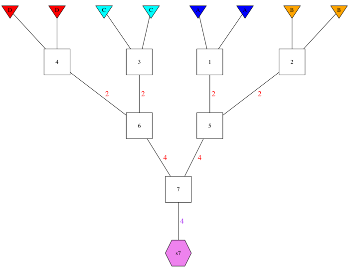

### Mapping populations/collections to founding populations. `RepPop`

When you create a genomic simulation pedigree, you will typically denote the groups/populations/clusters that the founders come from with short names, like “A” or “B”. However, the actual group names used in your genotype dataset (as specified in `I_meta`) might be different. In our example data for this R package, we have 4 groups. To quickly illustrate how many individuals are included in each of these example groups:

```r
I_meta %>%
  count(group)
```

```
#> # A tibble: 4 × 2
#>   group     n
#>   <chr> <int>
#> 1 Pop1     20
#> 2 Pop2     20
#> 3 Pop3     18
#> 4 Pop4     20
```

To define how individuals among groups combine to form hybrids, you must use a tibble with columns `index`, `pop`, `group`, to indicate which of the founding populations (“A”, “B”, etc.) correspond to the different groups (from the `group` column in, for example, `I_meta`) in your genotype data set; thus, the `RepPop` serves to translate/align your `I_meta` with your `GSP`.

If you wish to iterate the segregation procedure multiple times in a single simulation—each time assigning new genetic material to the founders of the pedigree—you can specify that by doing multiple replicates of the procedure as defined in the `index` column. The `index` column must be of type integer, and it must include all values from 1 up to the number of simulation replicates desired. Rows with the same value, $i$, say, of `index` give the desired mappings from founding pops (“A”, “B”, etc) in the GSP to different groups in the genotype data for the $i^{\mathrm{th}}$ replicates of the simulation.

Each different replicate is made by drawing genetic material *without replacement* from the genotypes (`Geno` in the example data) and placing that genetic material into the founders of the GSP. Sampling of alleles from the haplotypes within Geno into the founders of the GSP is always done without replacement within the specification of a particular RepPop. (Thus, for example, if you have indexes from 1 to 20, with each one mapping three A founders to individuals in Pop1 and four B founders to individuals in Pop2, then you will need to have genotypes from at least $20\times 3$ individuals in Pop1 and $20\times 4$ individuals in Pop2).

An example might help. Suppose that we wish to do a simulation with the pedigree in `GSP` (13 individuals, 6 of which are founders: 3 from population “A” and 3 from population “B”). For the first replicate (`index` = 1), we might want to map “A” to Pop1 and “B” to Pop2, and in the second replicate (`index` = 2) we might want to map “A” to Pop4, and “B” to Pop 3. Note, at this point, genetic material from 3 individuals from each of those populations will have been “consumed” from each of these populations and segregated, without replacement, into the samples from the genomic simulation pedigree.

The `RepPop` tibble that would specify this is given in the package variable `RepPop1`:

```r
RepPop1
```

```
#> # A tibble: 4 × 3
#>   index pop   group
#>   <int> <chr> <chr>
#> 1     1 A     Pop1
#> 2     1 B     Pop2
#> 3     2 A     Pop4
#> 4     2 B     Pop3
```

For another example, imagine that we want to do three replicates (`index` = 1:3) creating the admixed individuals sampled from the genomic permutation pedigree, `gsp4`. The RepPop tibble for that might look like this:

```r
RepPop4
```

```
#> # A tibble: 12 × 3
#>    index pop   group
#>    <int> <chr> <chr>
#>  1     1 A     Pop1
#>  2     1 B     Pop2
#>  3     1 C     Pop3
#>  4     1 D     Pop4
#>  5     2 A     Pop1
#>  6     2 B     Pop2
#>  7     2 C     Pop3
#>  8     2 D     Pop4
#>  9     3 A     Pop1
#> 10     3 B     Pop2
#> 11     3 C     Pop3
#> 12     3 D     Pop4
```

## Segregating Chunks of Genome Without Replacement

Now that we have been through all of the input data formats, we can use them to segregate chunks of chromosome. Note that this first part does not require genotypes. We are just simulating the process by which big chunks of chromosomes drop through the pedigrees. The function used for this is `segregate()`. The needed inputs are:

- 1 or more genomic permutation pedigrees (like `GSP` or `gsp4`)
- A RepPop tibble to go with each genomic permutation pedigree
- The recombination probabilities, like `RecRates`.

The final wrinkle here is that we have set this up so that you can specify, in a single simulation, that replicates from multiple genomic permutation pedigrees can be requested. This is done by passing `segregate()` a tibble that has a list column named `gpp`, which holds the genomic permutation pedigrees, and a parallel column named `reppop`, which holds the RepPop tibbles for each of those genomic permutation pedigrees.

```r
Input_tibble <- tibble(
  gpp = list(gspComplex),
  reppop = list(RepPopSimpleF1)
)

# here is what that input object looks like:
Input_tibble
```

```
#> # A tibble: 1 × 2
#>   gpp               reppop
#>   <list>            <list>
#> 1 <tibble [7 × 11]> <tibble [2 × 3]>
```

The segregation requested is then carried out, using the recombination rates in `RecRates` like this:

```r
set.seed(15) # for reproducibility
Segments <- segregate(
  request = Input_tibble,
  RR = RecRates
)
```

The output from that is a big tibble. Each row represents one segment of genetic material amongst the sampled individuals from the genomic permutation pedigrees. Each segment exists in one of the samples (`samp_index`) from a sampled individual with a `ped_sample_id` on a given `gpp` (the index giving the row of the request input tibble) in a given `rep` within the individual. Further, it is on one of two gametes (`gamete_index`) that segregated into the individual, and it came from a certain founding population (`pop_origin`) that corresponds to the named groups in the genotype file (`group_origin`). And, of course, the segment occupies the space from `start` to `end` on a chromosome `chrom`. Finally, the index of the founder haplotype on the given gpp that this segement descended from is given in `rs_founder_haplotype` which is short for “rep-specific founder haplotype”. This final piece of information is crucial for segregating variation from the individuals in the `Geno` file onto these segments. We take that up in the next section, but let’s first look at the results that we have here.

First, here is a listing of the top of the `Segments` we produced above.

```r
Segments
```

```
#> # A tibble: 36 × 14
#>    chrom_f   gpp index chrom ped_sample_id samp_index gamete_index
#>    <fct>   <int> <int> <chr> <chr>              <int>        <dbl>
#>  1 12          1     1 12    5                      1            1
#>  2 17          1     1 17    5                      1            1
#>  3 18          1     1 18    5                      1            1
#>  4 12          1     1 12    5                      1            2
#>  5 17          1     1 17    5                      1            2
#>  6 18          1     1 18    5                      1            2
#>  7 12          1     1 12    6                      1            1
#>  8 17          1     1 17    6                      1            1
#>  9 18          1     1 18    6                      1            1
#> 10 12          1     1 12    6                      1            2
#> # ℹ 26 more rows
#> # ℹ 7 more variables: gamete_segments <list>, pop_origin <chr>,
#> #   rs_founder_haplo <int>, start <dbl>, end <dbl>, group_origin <chr>,
#> #   sim_level_founder_haplo <int>
```

The table is a little wide, so we will show the first half of the columns and then the second half.

First half

```r
Segments %>%
  select(gpp:pop_origin)
```

```
#> # A tibble: 36 × 8
#>      gpp index chrom ped_sample_id samp_index gamete_index gamete_segments
#>    <int> <int> <chr> <chr>              <int>        <dbl> <list>
#>  1     1     1 12    5                      1            1 <dbl [2]>
#>  2     1     1 17    5                      1            1 <dbl [2]>
#>  3     1     1 18    5                      1            1 <dbl [2]>
#>  4     1     1 12    5                      1            2 <dbl [2]>
#>  5     1     1 17    5                      1            2 <dbl [2]>
#>  6     1     1 18    5                      1            2 <dbl [2]>
#>  7     1     1 12    6                      1            1 <dbl [2]>
#>  8     1     1 17    6                      1            1 <dbl [2]>
#>  9     1     1 18    6                      1            1 <dbl [2]>
#> 10     1     1 12    6                      1            2 <dbl [3]>
#> # ℹ 26 more rows
#> # ℹ 1 more variable: pop_origin <chr>
```

Second half

```r
Segments %>%
  select(rs_founder_haplo:group_origin)
```

```
#> # A tibble: 36 × 4
#>    rs_founder_haplo start       end group_origin
#>               <int> <dbl>     <dbl> <chr>
#>  1                1     0 63582536  Pop1
#>  2                1     0 69302804  Pop1
#>  3                2     0 61201108  Pop1
#>  4                1     0 63582536  Pop2
#>  5                1     0 69302804  Pop2
#>  6                2     0 61201108  Pop2
#>  7                4     0 63582536  Pop1
#>  8                4     0 69302804  Pop1
#>  9                3     0 61201108  Pop1
#> 10                2     0 17363020. Pop1
#> # ℹ 26 more rows
```

### Visualizing those chunks of genome

Let’s glance at the gspComplex (also illustrated above):

[figure not shown]

For convenience, we built a function called `plot_simulated_chromosome_segments()` that let’s you quickly visualize the results. Let’s try it here. By adding the RecRates to the function call, we get little sparklines showing us the recombination rates across the chromosomes.

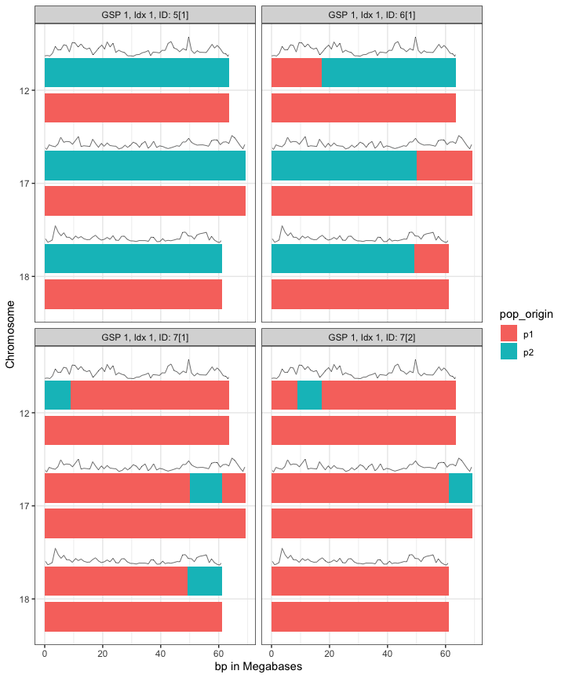

```r
g <- plot_simulated_chromomsome_segments(Segments, RecRates)
g
```

As you can see, Individual #5 (F1 specified in the GSP above) represents full chromosomes from Pop1 and Pop2, without recombination, at each of the 3 chromosomes included in the example data. As described in the GSP, one of the F1s was carried down the pedigree to simulate an F1BC1 (Individual #6).  
The chromosomal composition of Individual 6 illustrates the effect of recombination.  
Similarly, one of the F1BC1s was carried down to simulate an F1BC2 (Individuals #7). Here we have two #7s, illustrating distinct patterns of recombination.

## Simulating alleles at markers within segments

There are a few separate steps required to make this happen, and they all occur within the function `segments2markers()`. The steps that happen are:

1. The genotype matrix is reorganized according to the `group` specification in the `I_meta`, so that individuals in the same group are adjacent to one another in the genotype matrix.
2. The alleles carried by the individuals within each population are permuted.
3. The chromosomes carrying these permuted alleles from `Geno` are mapped to the chromosomes carried by the founders in the simulation performed by `segregate()`.
4. The alleles on the founder chromosomes are propagated to the descendant segments in the individuals sampled from the GSP.
5. Missing data is dealt with (if a site has one gene copy missing after the permutation and mapping described above, the other gene copy must be declared missing, as well).
6. The output genotypes are formatted for return, along with some information about the true admixture proportions of each individual.

The input to `segments2markers()` is:

- A tibble of segments, like that returned from `segments()`. We could use the variable `Segments` defined above in this vignette example, but we will re-run the `segregate()` step, here, explicitly including the marker meta data. This is helpful because it re-orders chromosomes, if necessary, and checks that all the markers are included within the bounds of the recombination rate bins.
- The individual meta data,
- The marker meta data,
- The genotype data.

We invoke it like this:

```r
set.seed(15) # for reproducibility
# re-run segment segregation, explicitly passing it the
# marker meta data
Segments2 <- segregate(
  request = Input_tibble,
  RR = RecRates,
  MM = M_meta
)

Markers <- segments2markers(
  Segs = Segments2,
  Im = I_meta,
  Mm = M_meta,
  G = Geno
)
```

The output is a list of three components:

- `Markers$ret_geno` is an N x 2L matrix of returned genotypes. The two alleles at each locus are in two adjacent columns.

  ```r
  dim(Markers$ret_geno)
  ```

  ```
  #> [1]  78 200
  ```

  ```r
  # genotypes of the first 10 individuals at the first 3 markers
  Markers$ret_geno[1:10, 1:6]
  ```

  ```
  #>       [,1] [,2] [,3] [,4] [,5] [,6]
  #>  [1,] "G"  "G"  NA   NA   "T"  "T"
  #>  [2,] "G"  "G"  NA   NA   "T"  "T"
  #>  [3,] "G"  "G"  "C"  "C"  "T"  "T"
  #>  [4,] "G"  "G"  "C"  "C"  "T"  "C"
  #>  [5,] "G"  "G"  "C"  "C"  "T"  "T"
  #>  [6,] "G"  "G"  "C"  "C"  "T"  "T"
  #>  [7,] "G"  "G"  "C"  "C"  "T"  "T"
  #>  [8,] "G"  "G"  "C"  "C"  "T"  "T"
  #>  [9,] "G"  "G"  NA   NA   "T"  "T"
  #> [10,] "G"  "G"  "C"  "C"  "T"  "T"
  ```

- `$ret_ids`: a tibble with IDs of the individuals corresponding to the rows in the `ret_geno` matrix.

  ```r
  # Individual IDs for the first 10 individuals
  Markers$ret_ids[1:10,]
  ```

  ```
  #> # A tibble: 10 × 2
  #>    group    indiv
  #>    <chr>    <chr>
  #>  1 ped_hybs h-1-1-5-1-1
  #>  2 ped_hybs h-1-1-6-1-2
  #>  3 ped_hybs h-1-1-7-1-3
  #>  4 ped_hybs h-1-1-7-2-4
  #>  5 Pop1     permed_ID0016971
  #>  6 Pop1     permed_ID0016972
  #>  7 Pop1     permed_ID0017013
  #>  8 Pop1     permed_ID0023170
  #>  9 Pop1     permed_ID0035746
  #> 10 Pop1     permed_ID0035748
  ```

  There are two columns: `group` and `indiv`. The first rows include the samples simulated as specified in the GSP. Their group is `ped_hybs` (meaning “sampled hybrids from the pedigree”) and their IDs are in the `indiv` column in the format of an `h-` followed by a string with replaced values of: `gpp-rep-ped_sample_id-samp_index-matrix_row`. Let’s break down the nomenclature we used to label simulated gentype. Recall with this simulation, we specified only a single `GSP` (in the Input_tibble gpp = list(gspComplex).  
  With this `gspComplex`, we are using 3 founders from Pop1 and 1 founder from Pop2 to simulate one F1 (Individual #5 as described with `gspComplex` above), one F1BC1 (Individual #6) and two F1BC2s (Individual #7). Within the illustration of `gspComplex`, as called from the Input_tibble…

  Those are:
  - `index`: the `index` value from the `RepPop` object (only a single `index` in this example)
  - `ped`: the number corresponding to the unique GSP used in the simulation (recall that you can specify multiple GSPs by passing `segregate()` a list named `gpp` which holds the genomic permutation pedigrees used in the simulation, but we only passed 1 GSP in that list),
  - `sample_id`: corresponding sample number from the GSP (recall that multiple individuals simulated within the pedigree [non-founders] may share the same sample number, but these IDs correspond to #5, #6, and two #7s with `gspComplex`)
  - `samp_index`: indexing of individuals within `sample_id`s (one #5[F1], one #6 [F1BC1], and two #7s [F1BC2])
  - `matrix_row`: the row number of the genotype matrix

  After the individual hybrid samples from the pedigree, there are rows of all the remaining individuals whose genotypes after permutation were not involved as founders in the segregation simulation. These are given the name `permed` + their original IDs. The group that each belongs to is in the group column. Things are organized this way so that the whole genotype can easily be passed to ADMIXTURE and the admixture fractions of the hybrid individuals estimated using the `permed_*` individuals as samples of known cluster/group origin.
- `$hyb_Qs`: A tibble with the true admixture fraction (calculated as the total proportion of genome length from each group) of each simulated hybrid.

Now, briefly, we can illustrate this again with more complexity. Let’s illustrate the capacity to simulate multiple genomic permutation pedigrees (GSP and gsp4 illustrated below) by passing `segregate()` a tibble that has a list column named `gpp`, which holds the genomic permutation pedigrees, and a parallel column named `reppop`, which holds the RepPop tibbles for each of those genomic permutation pedigrees.

```r
Input_tibble <- tibble(
  gpp = list(GSP, gsp4),
  reppop = list(RepPop1, RepPop4)
)

# here is what that input object looks like:
Input_tibble
```

```
#> # A tibble: 2 × 2
#>   gpp                reppop
#>   <list>             <list>
#> 1 <tibble [13 × 11]> <tibble [4 × 3]>
#> 2 <tibble [7 × 11]>  <tibble [12 × 3]>
```

```r
set.seed(15) # for reproducibility
Segments <- segregate(
  request = Input_tibble,
  RR = RecRates
)
```

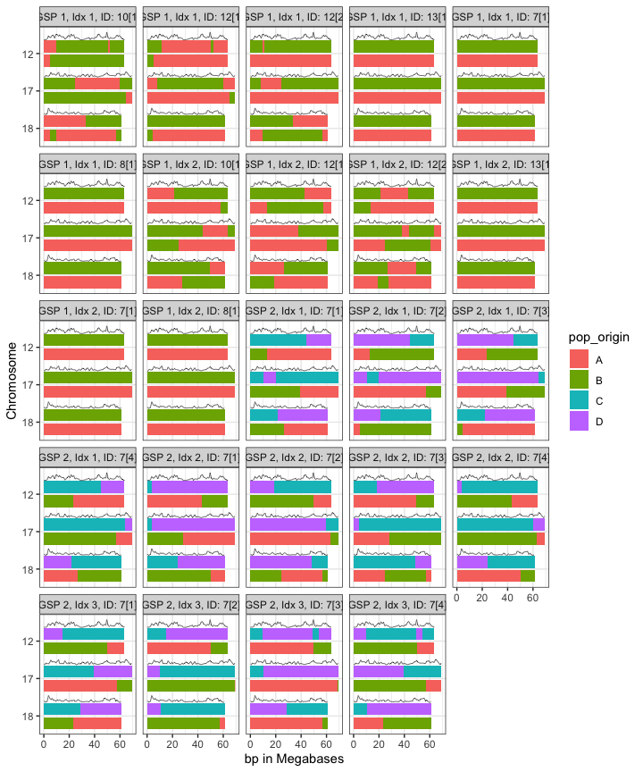

```r
g <- plot_simulated_chromomsome_segments(Segments, RecRates)
g
```

```r
Markers <- segments2markers(
  Segs = Segments,
  Im = I_meta,
  Mm = M_meta,
  G = Geno
)
```

## To and From plink Format

Now that we have illustrated the application of ‘gscramble’ with this simple dataset and the included R objects `Geno`, `I_meta`, and `M_meta`, you are probably eager to try ‘gscramble’ with data of your own. Use the function `plink2gscramble()` to directly input genotypes in the PLINK (.ped / .map) format. You must pass the function `plink2gscramble()` both the .ped and corresponding .map files as illustrated below. If your data is in a binary PLINK format (.bed / .bim / .fam), first use PLINK (option `--recode`) to export .ped and .map files that are accessible for ’gscramble’s `plink2gscramble()`.

```r
####### These lines are not portable, since gscrambleTutorial.ped and
####### gscrambleTutorial.map are not available
# with .ped / .map files

#plinkIN <- plink2gscramble(ped = "gscrambleTutorial.ped", map = "gscrambleTutorial.map")
#ls(plinkIN)
#str(plinkIN)

#dim(plinkIN$Geno)
#plinkIN$Geno[1:3,1:10]

#rm(plinkIN)

# identifical result with corresponding .ped.gz / .map.gz files
###### End non-portable lines

map_plink <- system.file("extdata/example-plink.map.gz", package = "gscramble")
ped_plink <- system.file("extdata/example-plink.ped.gz", package = "gscramble")

plinkIN <- plink2gscramble(ped_plink, map_plink)
dim(plinkIN$Geno)
```

```
#> [1]  78 200
```

```r
dim(plinkIN$I_meta)
```

```
#> [1] 78  6
```

```r
dim(plinkIN$M_meta)
```

```
#> [1] 100   4
```

Or, if you want to just pass the prefix to the ped and the map files, you could use:

```r
prefix <- system.file("extdata/example-plink.map.gz", package = "gscramble")
prefix <- str_replace(prefix, "\\.map\\.gz", "")

plinkPRE <- plink2gscramble(prefix = prefix, gz_ext = TRUE)
dim(plinkPRE$Geno)
```

```
#> [1]  78 200
```

```r
dim(plinkPRE$I_meta)
```

```
#> [1] 78  6
```

```r
dim(plinkPRE$M_meta)
```

```
#> [1] 100   4
```

Here, we use the `gz_ext = TRUE` option because our files are gzipped with the `.gz` extension.

When it is time to write out a set of plink files, you can use `gscramble2plink()`:

```r
# note, we are only using a temporary file here for the output
# because this is in the vignette of an R package.  You, yourself,
# will likely want to write the results to a directory in your
# home directory somewhere, like `prefix = ~/my_stuff/gscram-sim-1`, etc.
tfile <- tempfile()
gscramble2plink(
  I_meta = Markers$ret_ids,
  M_meta = M_meta,
  Geno = Markers$ret_geno,
  prefix = tfile
)
```

```
#> pedfile written to /var/folders/xg/mz_qt7q54yv_hwzvhskwx2c00000gp/T//Rtmpk0Uwgy/file17e7c3617706a.ped
#> mapfile written to /var/folders/xg/mz_qt7q54yv_hwzvhskwx2c00000gp/T//Rtmpk0Uwgy/file17e7c3617706a.map
#> [1] TRUE
```